# Lesson 7: Economic Growth

## What is Economic Growth?

Economic growth is an increase in living standards, which has traditionally been measured using Real GDP per capita.

# Chapter Six: Solow Growth Model

## Notation

- L<sub>t</sub> - Number of workers
- n - growth rate of work force
  - population growth rate
- K<sub>t</sub> - capital stock
- $\delta$ - depreciation rate
- Y<sub>t</sub> - output (GDP)
- C<sub>t</sub> - consumption
- I<sub>t</sub> - gross investment
  - $C_t = Y_t - I_t$
- $y_t = \frac{Y_t}{L_t}$ - ouput per worker
- $c_t = \frac{C_t}{L_t}$ - consumption per worker
- $k_t = \frac{K_t}{L_t}$ - capital per worker (capital-labor ratio)
- $i_t = \frac{I_t}{L_t}$ - investment per worker

## Big Finding of Solow Model

In the solow model, if the is no productivity growth (an increase in TFP A), then the economy reaches a steady state. At a steady state y<sub>t</sub>, k<sub>t</sub>, and c<sub>t</sub> are all constant while Y, K, and C will grow at the rate n (population growth rate).

## Steady-State of Investment

I<sub>t</sub> (Investment) serves two main purposes:

1. Expand the size of capital stock (K<sub>t</sub>)
2. Replace depreciated capital ($\delta K_t$)

Since in steady state we know that capital stock K<sub>t</sub> will grow at the rate n, we can conclude that $I_t = nK_t + \delta K_t$, which brings per worker steady state of investment to:
$$i = (n + \delta)k$$

## Per-Worker Production Function

Recall that we stated $Y = AF(K, L)$. We can add the time aspect in to get $Y_t = AF(K_t, L_t)$. Now let’s find the per-worker equation:
$$\frac{Y_t}{L_t} = \frac{AF(K_t, L_t)}{L_t}$$
$$\frac{Y_t}{L_t} = A\frac{1}{L_t}F(K_t, L_t)$$
From here, if the function F(K<sub>t</sub>, L<sub>t</sub>) has constant return to scales we can conclude:
$$\frac{Y_t}{L_t} = AF(\frac{K_t}{L_t}, \frac{L_t}{L_t})$$
Which in our notation is
$$y_t = Af(k_t)$$

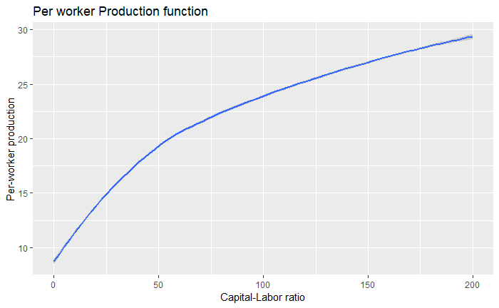

## Steady-State of Consumption

We know two things:

1. $C_t = Y_t - I_t$
2. $I_t = (n + \delta)K_t$ at steady state

So we can conlude that $C_t = Y_t - (n + \delta)K_t$ and per worker we get:
$$c = y - (n + \delta)k$$
$$c = Af(k) - (n + \delta)k$$

If capital increases what happens to production?

- If k increases, then $f(k)$ increases, but at a decreasing rate, so c (consmumption increases)
- If k increases, then $(n + \delta)k$ increases, but at a rate of $(n + \delta)$, so c (consumption decreases)

What happens if we try to maximize consumption? (not related to steady state)

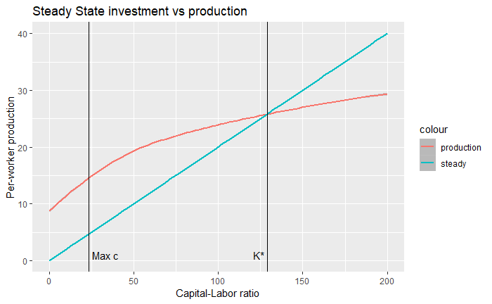

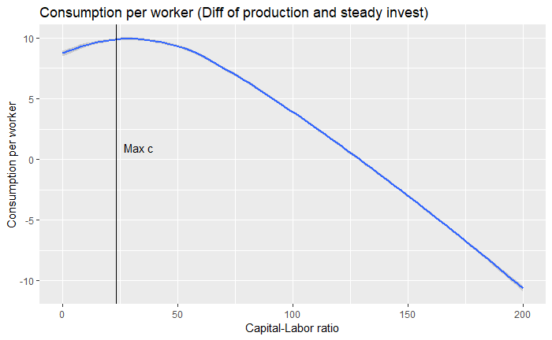

The maximum of consumption happens at the value of k with the biggest difference of y and $(n + \delta)k$. Consumption comes back down to zero where production is equal to $(n + \delta)k$.